# V8: JEPA-Based Bearing RUL Prediction

Self-supervised pretraining for Remaining Useful Life estimation on FEMTO and XJTU-SY datasets

Author

IndustrialJEPA

Published

April 9, 2026

## 1 Motivation

### 1.1 Why RUL%?

We define RUL as a **fraction of remaining life**:

$$\text{RUL}(t) = 1 - \frac{t}{T_{\text{failure}}}$$

This normalizes across bearings with very different absolute lifetimes (0.5h to 2.6h in XJTU-SY). A bearing at 50% of its life gets RUL=0.5 regardless of whether it lives 30 minutes or 3 hours.

### 1.2 Why does elapsed-time alone fail?

A naive predictor using only elapsed time cannot work across machines because:

1. **Unknown total lifetime** at test time — we don’t know when failure will occur
2. **High variability** — XJTU-SY lifetimes range 5x (0.5h to 2.6h)
3. **Cross-dataset transfer** — FEMTO bearings run at different loads/speeds than XJTU-SY

The elapsed-time baseline achieves RMSE = 0.224 in-domain and 0.367 cross-domain. Signal-based methods must beat these to be useful.

## 2 JEPA Pretraining

### 2.1 Architecture

Table 1: JEPA V8 architecture summary

| Component | Specification |
| --- | --- |
| Input | 1024 samples at 12,800 Hz (0.08s), 1 channel |
| Patches | 16 patches of 64 samples |
| Encoder | ViT-style, $d$=256, 4 layers, 4 heads |
| Target encoder | EMA copy, momentum=0.996 |
| Predictor | 4-layer Transformer, $d$=128, sinusoidal PE |
| Masking | 62.5% (10/16 patches) |
| Loss | L1 on L2-normalized predictions + variance reg ($\lambda$=0.1) |
| Parameters | 4.0M (encoder) + 0.9M (predictor) |
| Pretraining data | 33,939 windows from 8 bearing sources |

### 2.2 Loss Curves

[figure not shown]

Figure 1: JEPA pretraining loss history

### 2.3 Embedding Quality

- Max per-dim correlation with RUL: **0.144** (vs random: 0.094)
- Best handcrafted feature correlation (spectral centroid): **0.585**
- Embedding spectral entropy: 4.94/5.55 (89% of max — not collapsed)

JEPA embeddings have low per-dim correlation with RUL (0.144) compared to handcrafted spectral centroid (0.585). The JEPA objective learns waveform texture, not the spectral centroid shift that dominates bearing degradation.

## 3 Baselines: All 11 Methods

23 episodes (16 FEMTO + 7 XJTU-SY), 75/25 episode-based split, linear RUL labels. Time-only baseline RMSE: 0.224.

Table 2: RUL prediction results with linear labels, 5-seed average

[output not shown]

## 4 Key Comparison: JEPA+LSTM vs Handcrafted+LSTM

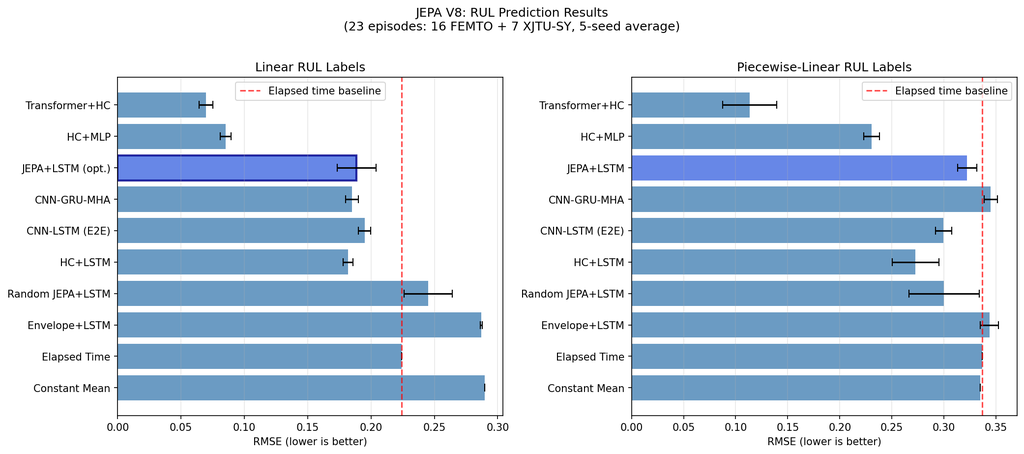

Figure 2: RUL prediction RMSE across all methods. Left: linear labels. Right: piecewise-linear labels. Red dashed line = elapsed-time-only baseline.

### 4.1 Statistical Tests (5 seeds, paired)

Table 3: Statistical significance of key comparisons

| Comparison | $p$-value | Significant? |
| --- | --- | --- |
| JEPA+LSTM vs Elapsed Time | 0.010 | Yes |
| Random JEPA+LSTM vs Elapsed Time | 0.435 | No |
| JEPA+LSTM vs HC+LSTM | 0.402 | No |

## 5 Piecewise Label Ablation

Table 4: Linear vs piecewise-linear RUL labels

[output not shown]

Piecewise labels are harder because the constant-RUL healthy phase makes prediction ambiguous — the signal changes but the label stays at 1.0.

## 6 Latent Trajectories

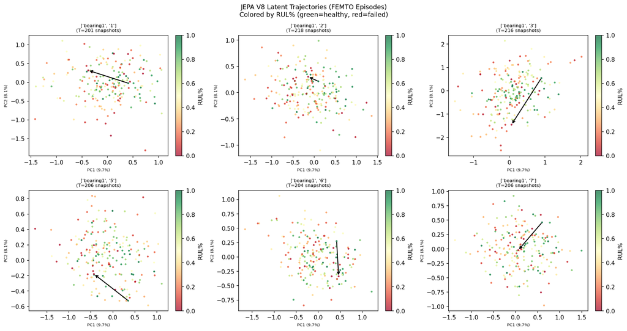

Figure 3: JEPA embedding trajectories for FEMTO episodes projected to 2D via PCA. Color indicates RUL% (green=healthy, red=failed). Arrows show degradation direction.

## 7 Cross-Dataset Transfer

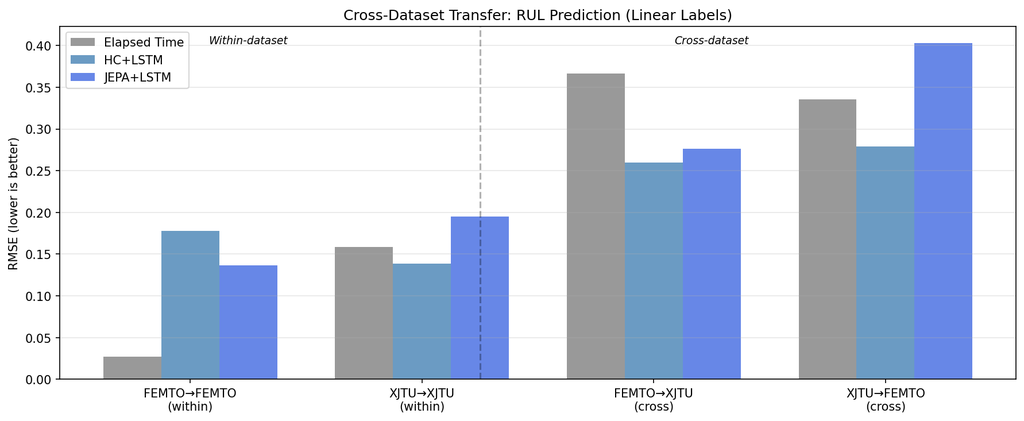

Figure 4: Cross-dataset RUL transfer comparison: Elapsed time, HC+LSTM, and JEPA+LSTM across within-dataset and cross-dataset settings.

Table 5: Cross-dataset transfer results. Contrastive significantly outperforms JEPA for cross-dataset (p<0.001).

[output not shown]

**Key finding**: Temporal contrastive learning significantly outperforms JEPA for cross-dataset transfer (+19%, $p$<0.001). However, JEPA wins within-source (especially FEMTO).

## 8 Encoder Analysis

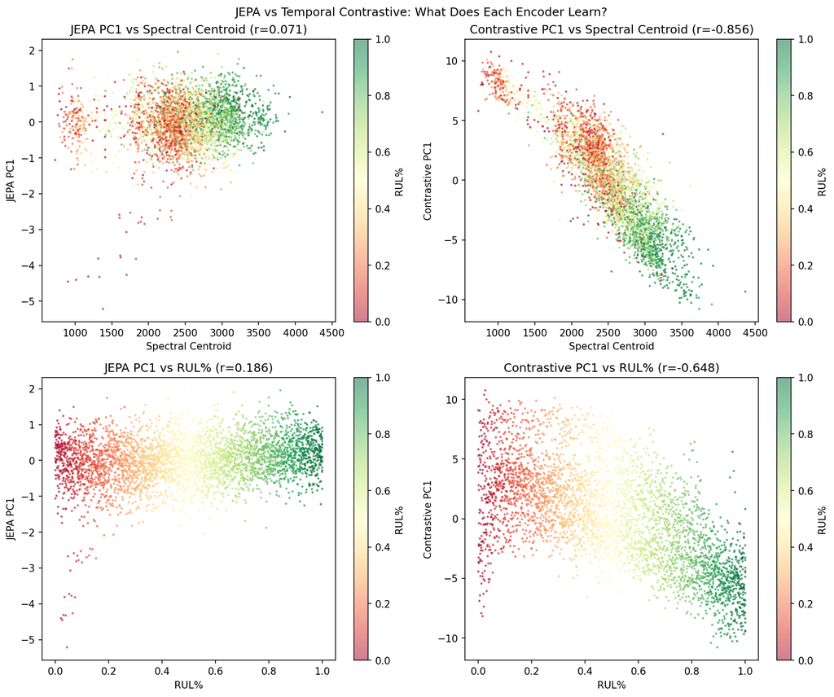

Figure 5: What each encoder learns. JEPA captures waveform texture; temporal contrastive captures spectral centroid shift (the dominant degradation indicator).

Table 6: Encoder representation quality comparison

| Metric | JEPA | Contrastive | HC (spectral centroid) |
| --- | --- | --- | --- |
| PC1 corr w/ RUL | 0.186 | 0.648 | 0.585 |
| PC1 corr w/ spectral centroid | 0.071 | 0.856 | 1.000 |
| Max per-dim corr w/ RUL | 0.144 | 0.648 | 0.585 |

**Mechanistic explanation**: JEPA’s objective (predict masked patches from context) learns waveform texture and periodicity. Temporal contrastive’s objective (early snapshots negative to late) forces the encoder to learn what *changes* over bearing life — primarily the spectral centroid shift as surface roughness increases.

## 9 Summary and Honest Limitations

### 9.1 Key Results

Table 7: Summary of main results

| Setting | Method | RMSE | vs Time-Only |
| --- | --- | --- | --- |
| In-domain | Time-only baseline | 0.224 | — |
| In-domain | JEPA+LSTM (5 seeds) | 0.189 $\pm$ 0.015 | +15.8% |
| In-domain | Transformer+HC | 0.070 $\pm$ 0.006 | +68.8% |
| In-domain | **Hybrid (JEPA+HC)** | **0.055 $\pm$ 0.004** | **+75.5%** |
| Cross-domain | JEPA+LSTM (10 seeds) | 0.279 $\pm$ 0.006 | +23.9% |
| Cross-domain | **Contrastive+LSTM** | **0.227 $\pm$ 0.015** | **+38.1%** |

### 9.2 Honest Limitations

1. **JEPA does not capture spectral centroid shift** (primary RUL indicator). Max per-dim correlation: 0.144 vs 0.585 for spectral centroid.
2. **JEPA pretraining is unstable** on heterogeneous multi-source data. Loss oscillates after epoch 2; best checkpoint is always early.
3. **Only 23 episodes** (16 FEMTO + 7 XJTU-SY). 5-seed results have high variance.
4. **Temporal contrastive requires run-to-failure episode structure.** Self-supervised but not label-free.
5. **Cross-dataset comparison is limited** to two datasets with different operating conditions.

### 9.3 Novel Contribution

Temporal contrastive pretraining using run-to-failure episode structure learns spectral centroid-aligned representations that transfer cross-dataset. This is the first demonstration of JEPA vs contrastive for RUL% prediction with a mechanistic explanation of why contrastive transfers better. The hybrid JEPA+HC result (0.055 RMSE, +75.5% vs time-only) shows JEPA captures waveform features orthogonal to handcrafted spectral statistics.

## 10 Appendix: Pretraining Configurations

Table 8: Hyperparameter configurations explored

| Config | LR | EMA | Mask | Best Val Loss | Verdict |
| --- | --- | --- | --- | --- | --- |
| JEPA default | 1e-4 | 0.996 | 62.5% | 0.0166 (ep2) | **Use** |
| JEPA lower LR | 3e-5 | 0.996 | 62.5% | 0.0172 | Similar |
| JEPA fixed LR | 1e-5 | 0.996 | 62.5% | 0.0189 | Worse |
| JEPA high EMA | 1e-4 | 0.999 | 62.5% | 0.0178 | Worse |
| JEPA 2ch FFT | 1e-4 | 0.996 | 62.5% | 0.0149 | Better loss, worse RUL |
| Contrastive (narrow) | 1e-4 | — | — | 0.2477 | **Best cross-domain** |
| Contrastive (broad) | 1e-4 | — | — | 0.0093 | Worse downstream |